# Into the Tidyverse: Cleaning SABAP Data

Alan Lee and Rebecca Irons (IRNREB001)

Due: 18 April 2022

**This document provides the step-by-step instructions to tidy SABAP2 data using the tidyverse to then create a plot of the probability of active moult in female and male sunbirds and the probability of a brood patch being present.The SABAP2 data can be accessed [here](https://sabap2.birdmap.africa/).** **The species code (SPP) can be changed to pull data of different species. The malachite sunbird (code: 751) is the focal species for this particular version of the document.**

### Section 1: install and load

Firstly, one’s workspace must be cleaned.

```r
rm(list=ls())
```

There are several packages that need to be installed to manipulate and tidy the SABAP2 data.

- Tidyverse is required to manipulate the data:

```r
install.packages("tidyverse", repos = "http://cran.us.r-project.org")
```

- RCurl and rjson is required to access the data from SABAP2 using as API.

```r
install.packages("RCurl", repos = "http://cran.us.r-project.org")

install.packages("rjson", repos = "http://cran.us.r-project.org")
```

The packages from the tidyverse have to be loaded. These packages are:

```r
library(dplyr)

library(ggplot2)

library(broom)
```

The packages required for loading in the data from the SABAP2 website are:

```r
library(RCurl)

library(rjson)
```

Using an API, access the SABAP2 database and load the data for your focal species.

```r
SPP = 751
ringing_data <- read.csv(paste('https://api.birdmap.africa/safring/species/records_list/',SPP,'?format=csv',sep=""))
```

### Section 2: tidying the SABAP2 data for a focal species

The ages that are recorded for the birds in the database must be numeric and the juveniles must be filtered out from the adults. We will only be working with adults.

```r
ringing_data$Age <- as.numeric(ringing_data$Age)

ringing_data <- filter(ringing_data, Age>3)
```

The metric data (tarsus length, mass etc) needs to be tidied. These data must be numeric.

```r
ringing_data$Mass <- as.numeric(as.character(ringing_data$Mass))

ringing_data$Wing <- as.numeric(as.character(ringing_data$Wing))

ringing_data$Culmen <- as.numeric(as.character(ringing_data$Culmen))

ringing_data$Head <- as.numeric(as.character(ringing_data$Head))

ringing_data$Tarsus <- as.numeric(as.character(ringing_data$Tarsus))
```

A common issue in the SAFRING database is that volunteers fill in some metric data in with a zero as opposed to leaving it blank. Therefore, these zeros need to be removed as a zero length - for example - does not make sense.

```r
ringing_data$Mass[ringing_data$Mass==0] <- NA

ringing_data$Wing[ringing_data$Wing==0] <- NA

ringing_data$Head[ringing_data$Head==0] <- NA

ringing_data$Culmen[ringing_data$Culmen==0] <- NA

ringing_data$Tarsus[ringing_data$Tarsus==0] <- NA

ringing_data$Tail[ringing_data$Tail==0] <- NA
```

```r
checkmass <- ringing_data%>%filter(!is.na(Mass))%>%do(data.frame(lc=quantile(.$Mass, c(.05)), uq=quantile(.$Mass, c(.995)), n=length(.$Mass) ))

checkWing <- ringing_data%>%filter(!is.na(Wing))%>%do(data.frame(lcwing=quantile(.$Wing, c(.005)), uqwing=quantile(.$Wing, c(.995)), n=length(.$Wing)))

checkTarsus <- ringing_data%>%filter(!is.na(Tarsus))%>%do(data.frame(lctarsus=quantile(.$Tarsus, c(.005)), uqtarsus=quantile(.$Tarsus, c(.995)), n=length(.$Tarsus)))

checkHead <- ringing_data%>%filter(!is.na(Head))%>%do(data.frame(lcHead=quantile(.$Head, c(.005)), uqHead=quantile(.$Head, c(.995)), n=length(.$Head)))

checkCulmen <- ringing_data%>%filter(!is.na(Culmen))%>%do(data.frame(lcCulmen=quantile(.$Culmen, c(.005)), uqCulmen=quantile(.$Culmen, c(.995)), n=length(.$Culmen)))

checkTail <- ringing_data%>%filter(!is.na(Tail))%>%do(data.frame(lcTail=quantile(.$Tail, c(.005)), uqTail=quantile(.$Tail, c(.995)), n=length(.$Tail)))


ringing_data$masscheck <- NA

ringing_data$wingcheck <- NA

ringing_data$headcheck <- NA

ringing_data$culmencheck <- NA

ringing_data$tailcheck <- NA
```

```r
for(k in 1:nrow(ringing_data)){

  ringing_data$masscheck[k] <- ifelse(ringing_data$Mass[k]<checkmass$uq & ringing_data$Mass[k]>checkmass$lc , "OK", "error")

  ringing_data$wingcheck[k] <- ifelse(ringing_data$Wing[k]<checkWing$uq & ringing_data$Wing[k]>checkWing$lc , "OK", "error")

  ringing_data$tarsuscheck[k] <- ifelse(ringing_data$Tarsus[k]<checkTarsus$uq & ringing_data$Tarsus[k]>checkTarsus$lc , "OK", "error")

  ringing_data$headcheck[k] <- ifelse(ringing_data$Head[k]<checkHead$uq & ringing_data$Head[k]>checkHead$lc , "OK", "error")

  ringing_data$culmencheck[k] <- ifelse(ringing_data$Culmen[k]<checkCulmen$uq & ringing_data$Culmen[k]>checkCulmen$lc , "OK", "error")

  ringing_data$tailcheck[k] <- ifelse(ringing_data$Tail[k]<checkTail$uq & ringing_data$Tail[k]>checkTail$lc , "OK", "error")
}
```

The ‘NAs’ then need to be replaced with ‘OK’ to soften the next filter step.

```r
ringing_data$masscheck[is.na(ringing_data$masscheck)] <- "OK"

ringing_data$tarsuscheck[is.na(ringing_data$tarsuscheck)] <- "OK"

ringing_data$headcheck[is.na(ringing_data$headcheck)] <- "OK"

ringing_data$culmencheck[is.na(ringing_data$culmencheck)] <- "OK"

ringing_data$tailcheck[is.na(ringing_data$tailcheck)] <- "OK"
```

The object containing the data for the focal species then needs to be redefined with the error filtered out.

```r
ringing_data <- filter(ringing_data, masscheck!='error', tarsuscheck!='error',headcheck!='error',culmencheck!='error',tailcheck!='error')
```

The column containing the brood patch information then needs to be cleaned so that the correct, and tidied data is plotted in Section 3.

```r
ringing_data$BP <-  as.numeric(ringing_data$Brood_patch)

ringing_data$BP <-  ifelse(ringing_data$BP >0 , 1, ringing_data$BP)

ringing_data$BP <-  ifelse(ringing_data$BP <0 , 0, ringing_data$BP)

ringing_data$BP <-  ifelse(ringing_data$Brood_patch %in% c("1.0", "2.0", "y", "BP", "Brood Patch") , 1, ringing_data$BP)

ringing_data$BP <-  ifelse(ringing_data$Brood_patch %in% c("-1.0", "n", "N", "no") , 0, ringing_data$BP)
```

The date information that is recorded in the SABAP2 database has to be cleaned and organized as well.

```r
ringing_data$Startdate1 <- as.Date(ringing_data$Startdate, "%Y-%m-%d")

ringing_data$Month <- format(ringing_data$Startdate1, "%m")

ringing_data$Month <- as.numeric(ringing_data$Month)

ringing_data$Year <- format(ringing_data$Startdate1, "%Y")
```

Next, the moult data must be numeric and filtered to remove NA values, which imply that active moult is not occurring.

```r
ringing_data$Moult <- as.numeric(ringing_data$Moult)

ringing_data <- filter(ringing_data, !is.na(Moult))

ringing_data$gender <- ifelse(ringing_data$Sex==1, "Male", ifelse(ringing_data$Sex==2, "Female", NA))

ringing_data$active_moult <- ifelse(ringing_data$Moult>0&ringing_data$Moult<5555555555, 1, 0)
```

### Section 3: plotting active moult and brood patch of the focal species

This last section provides the code to make a plot of the probability of active moult in female (pink line) and male (blue line) birds of the focal species, which in this case is the malachite sunbird. The probability of a brood patch (black line) is also included to visualize the relationship between active moult and a brood patch.

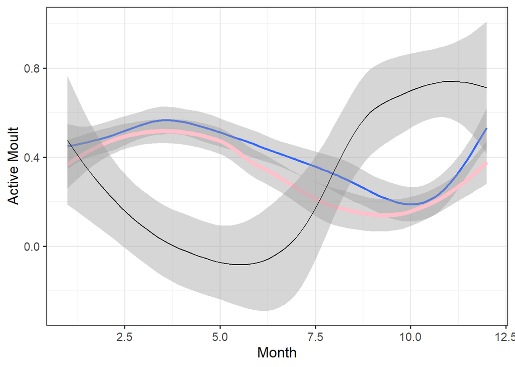

```r
ggplot(data = filter(ringing_data, Age==4, Sex%in%c(1)), aes(as.numeric(Month), active_moult))+
  geom_smooth() +xlab("Month") + ylab("Active Moult")+theme_bw(base_size = 14)+
  geom_smooth(data = filter(ringing_data, Age==4, Sex%in%c(2)), aes(as.numeric(Month), active_moult), colour="pink", size = 2)+
  geom_smooth(data = filter(ringing_data, Age==4, Sex%in%c(2)), aes(as.numeric(Month), BP), colour="black", size = 0.5)
```

And this is the final plot!